# Análise do Brasileirão

Lívia Cavalcanti, Marcus Vinícius

4 de junho de 2019

```r
dados_gols <- read_csv2(("campeonato-brasileiro-full.csv"))
```

```
## Using ',' as decimal and '.' as grouping mark. Use read_delim() for more control.
```

```r
head(dados_gols)
```

```
## # A tibble: 6 x 14
##   Horario Dia   Data  `Clube 1` `Clube 2` Vencedor Rodada Arena    p1    p2
##   <time>  <chr> <chr> <chr>     <chr>     <chr>    <chr>  <chr> <dbl> <dbl>
## 1 16:00   Sába~ 13/0~ Flamengo  Atlético~ -        1ª Ro~ Mara~     1     1
## 2 19:00   Sába~ 13/0~ Corinthi~ Chapecoe~ -        1ª Ro~ Aren~     1     1
## 3 11:00   Domi~ 14/0~ Fluminen~ Santos    Flumine~ 1ª Ro~ Mara~     3     2
## 4 16:00   Domi~ 14/0~ Cruzeiro  São Paulo Cruzeiro 1ª Ro~ Mine~     1     0
## 5 16:00   Domi~ 14/0~ Ponte Pr~ Sport     Ponte P~ 1ª Ro~ Mois~     4     0
## 6 16:00   Domi~ 14/0~ Palmeiras Vasco     Palmeir~ 1ª Ro~ Pale~     4     0
## # ... with 4 more variables: gols <dbl>, `C1 Estado` <chr>, `C2
## #   Estado` <chr>, `Vencedor Estado` <chr>
```

## 1. Jogos aos domingos têm mais gols que jogos às quartas?

```r
qua_dom_jogos <- dados_gols %>%
                    filter(Dia == "Domingo" | Dia == "Quarta-feira")
```

```r
theta_diferenca_gols <- function(df, i) {
  gols_df = df %>%
          slice(i) %>%
            group_by(Dia) %>%
              summarise(gols_media = mean(gols))

  dom = gols_df %>% filter(Dia == "Domingo") %>% pull(gols_media)
  qua = gols_df %>% filter(Dia != "Domingo") %>% pull(gols_media)

  dom - qua
}
```

```r
theta_hipotese_gols <- function(df) {
  gols_df = df %>%
            mutate(embaralhados_jogos = sample(Dia, n())) %>%
              group_by(embaralhados_jogos) %>%
                summarise(gols_media = mean(gols))

  dom = gols_df %>% filter(embaralhados_jogos == "Domingo") %>% pull(gols_media)
  qua = gols_df %>% filter(embaralhados_jogos == "Quarta-feira") %>% pull(gols_media)

  dom - qua
}
```

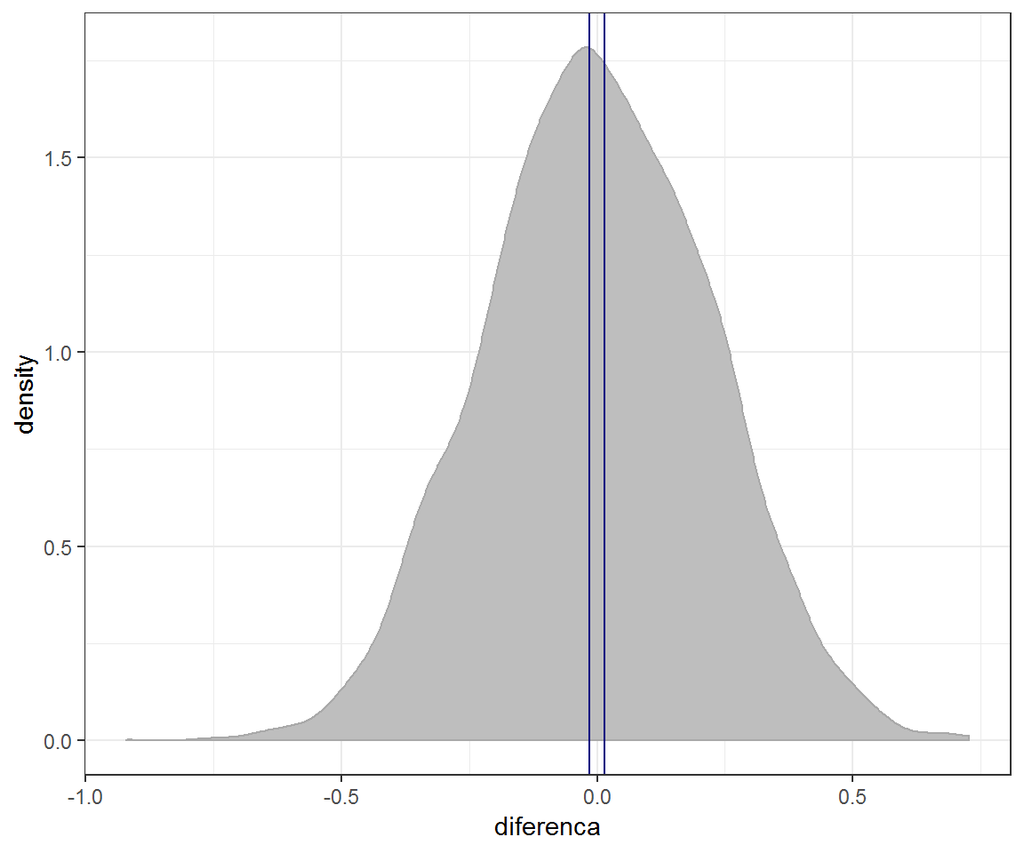

```r
diffs_gols = replicate(5000, {theta_hipotese_gols(qua_dom_jogos)})


tibble(diferenca = diffs_gols) %>%
  ggplot(aes(x = diferenca)) +
    geom_density(fill = "grey", color = "darkgrey") +
  geom_vline(xintercept = theta_diferenca_gols(qua_dom_jogos, 1:NROW(qua_dom_jogos)),
             color = "navy") +
    geom_vline(xintercept = - theta_diferenca_gols(qua_dom_jogos, 1:NROW(qua_dom_jogos)),
             color = "navy")
```

```r
mean(abs(diffs_gols) >= abs(theta_diferenca_gols(qua_dom_jogos, 1:NROW(qua_dom_jogos))))
```

```
## [1] 0.9638
```

Não há evidências para refutarmos a hipótese nula, ou seja, não podemos afirmar que jogos no domingo têm mais gols que os jogos de quarta, já que não foi encontrada diferença significativa entre os grupos (0.96) Pelo gráfico, é possível ver que o modelo nulo apresenta muitos casos que se enquadram nos dados passados como entrada.

```r
qua_dom_jogos %>%
    boot(statistic = theta_diferenca_gols, R = 4000) %>%
    tidy(conf.level = 0.95,
         conf.int = TRUE)
```

```
## # A tibble: 1 x 5
##   statistic     bias std.error conf.low conf.high
##       <dbl>    <dbl>     <dbl>    <dbl>     <dbl>
## 1   -0.0148 -0.00478     0.222   -0.451     0.420
```

O intervalo gerado obtido inclui o zero, logo não é possível afirmar que há diferença entre os dois grupos considerados.

## 2. Jogos onde há um vitorioso têm mais ou menos gols que empates?

```r
resultados_df <- dados_gols %>% mutate(resultado = ifelse(`Vencedor Estado` != "Empate", "Vitória", "Empate")) %>% select(resultado, gols)
```

```r
theta_diferenca_empates <- function(df, i) {
  gols_df = df %>%
          slice(i) %>%
            group_by(resultado) %>%
              summarise(gols_media = mean(gols))

  empate = gols_df %>% filter(resultado == "Empate") %>% pull(gols_media)
  vitoria = gols_df %>% filter(resultado == "Vitória") %>% pull(gols_media)

  empate - vitoria
}
```

```r
theta_hipotese_empates <- function(df) {
  gols_df = df %>%
            mutate(embaralhados_jogos = sample(resultado, n())) %>%
              group_by(embaralhados_jogos) %>%
                summarise(gols_media = mean(gols))

  empate = gols_df %>% filter(embaralhados_jogos == "Empate") %>% pull(gols_media)
  vitoria = gols_df %>% filter(embaralhados_jogos == "Vitória") %>% pull(gols_media)

  empate - vitoria
}
```

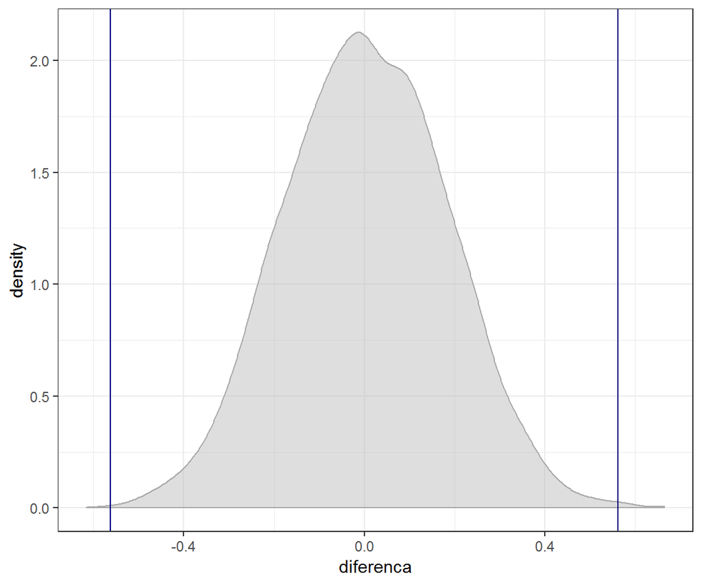

```r
diffs_empates = replicate(5000, {theta_hipotese_empates(resultados_df)})


tibble(diferenca = diffs_empates) %>%
  ggplot(aes(x = diferenca)) +
    geom_density(fill = "grey", color = "darkgrey", alpha=.5) +
  geom_vline(xintercept = theta_diferenca_empates(resultados_df, 1:NROW(resultados_df)),
             color = "navy") +
    geom_vline(xintercept = - theta_diferenca_empates(resultados_df, 1:NROW(resultados_df)),
             color = "navy")
```

```r
mean(abs(diffs_empates) >= abs(theta_diferenca_empates(resultados_df, 1:NROW(resultados_df))))
```

```
## [1] 0.0016
```

```r
resultados_df %>%
    boot(statistic = theta_diferenca_empates, R = 4000) %>%
    tidy(conf.level = 0.95,
         conf.int = TRUE)
```

```
## # A tibble: 1 x 5
##   statistic     bias std.error conf.low conf.high
##       <dbl>    <dbl>     <dbl>    <dbl>     <dbl>
## 1    -0.562 0.000448     0.175   -0.909    -0.226
```

Com confinça de 95%, há indícios de que há diferença entre a quantidade de gols entre jogos com empate e com vitória, tendo os jogos terminados com empate menos gols que os outros.

## c) Comparação de respostas

Em ambas as perguntas, as conclusões que foram obtidas tanto com intervalos de confiança quanto teste de hipotése via permutação convergem, porém, somente a partir dos intervalos de confiança nós podemos ter uma estimativa concreta de onde está o verdadeiro theta da população, métrica que não é possível ser estimada usando testes de hipotése via permutação, que apenas é passível de supor as conclusões com base na significância da diferença.

Essa ausência de métricas da população no teste de hipótese se dá justamente por ser um método que refuta ou confirma a hipótese nula.